# Mainstay Life Services Medication Errors Report

Helen Peng

## Exploratory Data Analysis

For shorthand purposes, I used following codebook:

- Missed dose = Missed a dose of medication
- Wrong dose = Gave too much or too little medication during a scheduled administration
- Extra dose = Gave an extra dose of medication that should not have been given
- Wrong medication = Gave medication that was supposed to be given for another reason
- Wrong time = Gave medication too early or too late
- Discontinued medication = Gave discontinued medication
- Wrong person = Gave someone else’s medication

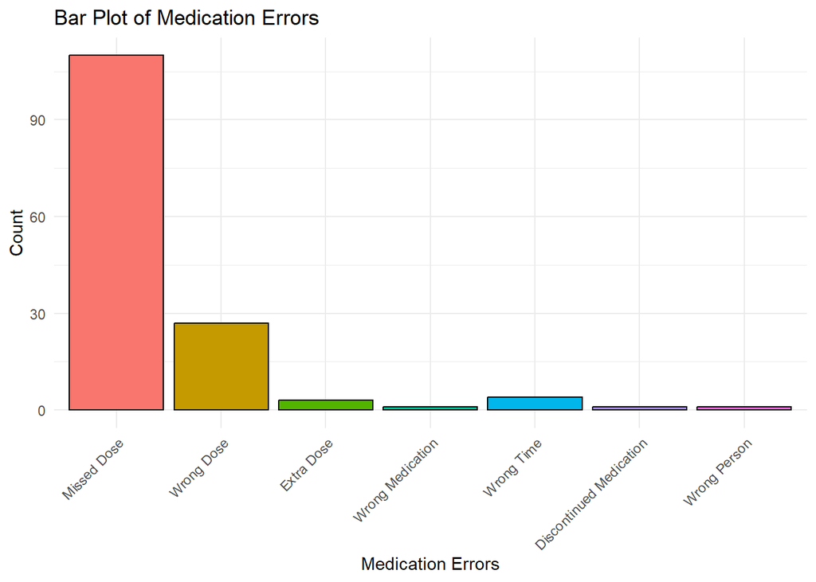

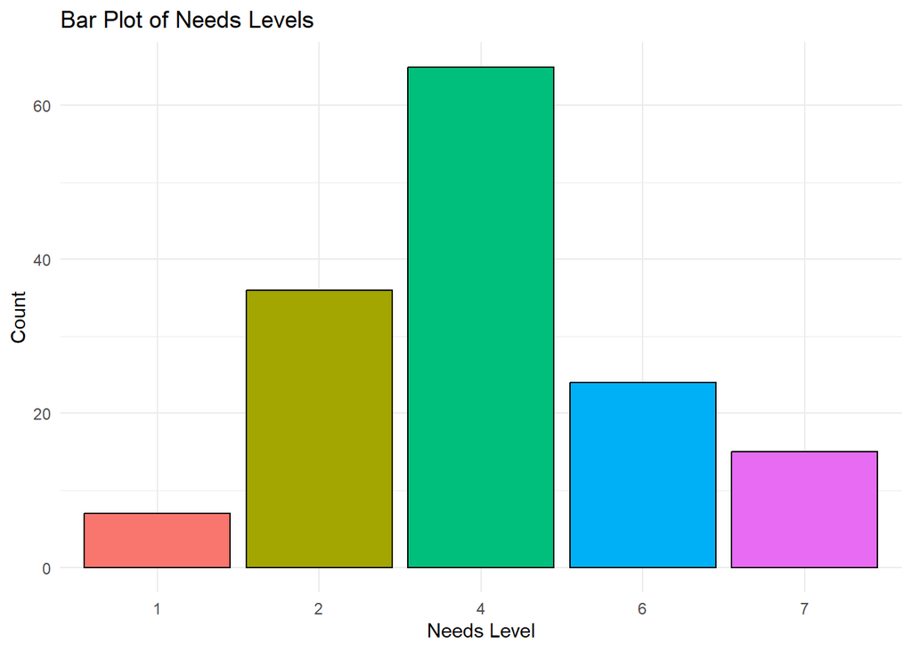

I found that the most common type of medication error is Missed Dose. Several factors could be preventing people from taking their medication on time, such as unclear instructions, unpleasant side effects, difficulties with access, complex medication regimens, forgetfulness, or a lack of support systems to remind patients, however the exact reason cannot be explored in this dataset.

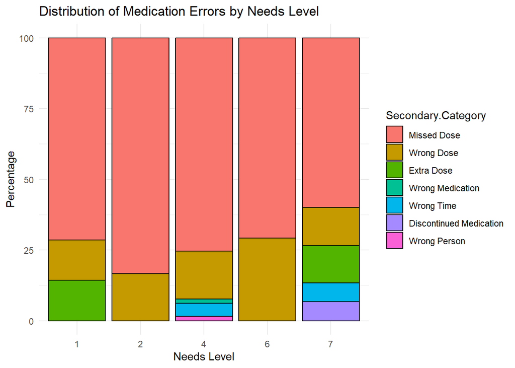

To examine the potential interaction between medication error type and needs level, I conducted a Fisher’s Exact Test, as some medication error types had small sample sizes. The result of the test (p = 0.1239) suggests that there is no significant association between the two variables (i.e., Secondary Category and Needs Level are independent). This indicates that there are no significant patterns or systematic relationships between the needs level and the type of medication error. In other words, the type of medication error is consistent across different needs levels, which is a positive outcome, as it suggests that errors are not biased by the needs level.

## Time Series Analysis

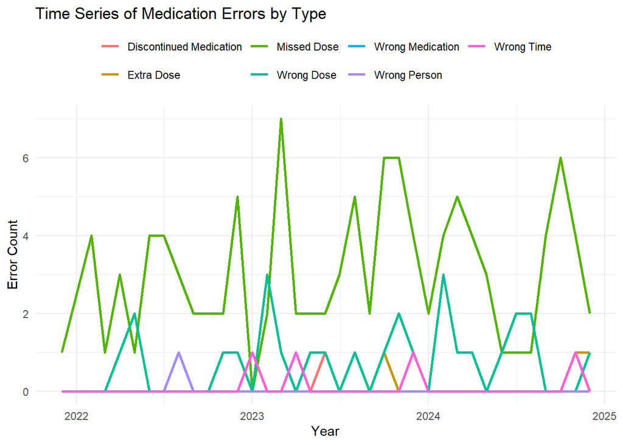

The most common months for errors were March 2023, October 2023, and November 2023, each with 8 errors, while the least common months were December 2021, March 2022, and January 2023, each with only 1 error. The most frequent medication errors over time are missed doses and wrong doses. To better understand these error types, I will decompose the time series data for further analysis.

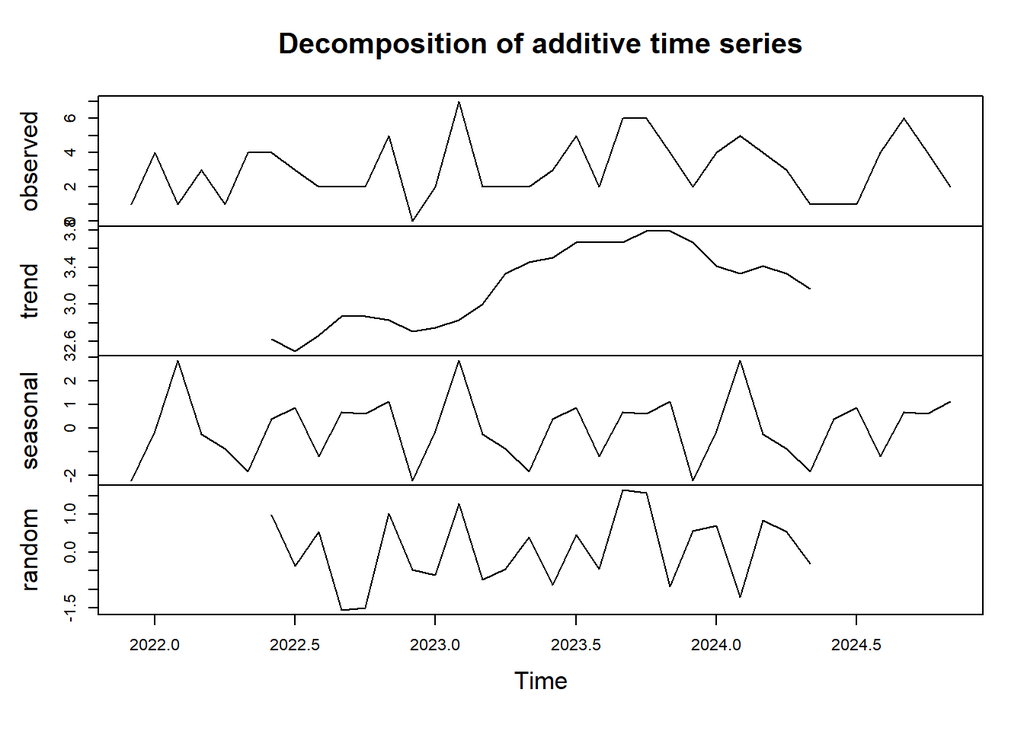

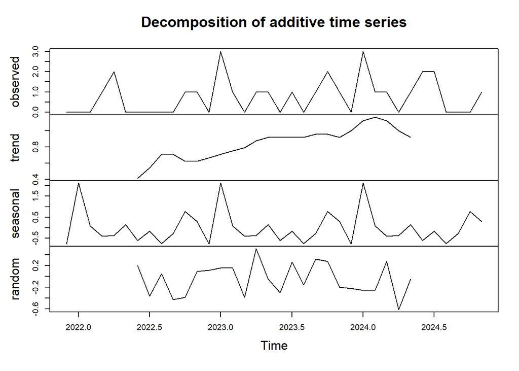

Additionally, from the decomposition, I found that both types of errors exhibit an overall increasing trend, there has been a recent decrease. Through Kruskal-Wallis test (once again because ANOVA assumptions were violated) showed no significant month-to-month differences (p = 0.468) for missed doses and no signiicant month-to-month differences (p = 0.456) for wrong doses.

## Survival Analysis

By treating reporting as the event of interest, I can use survival analysis to explore potential patterns in reporting times.

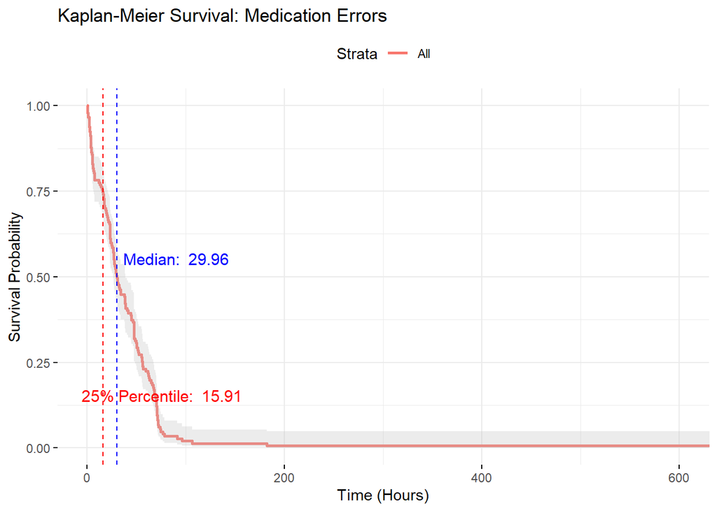

By 29.96 hours, $50\%$ of the population has reported their medication error case, by 15.91 hours, $25\%$ of the population have reported their medication error case, and by 74.21 hours, $95\%$ of the population has reported their medication error case.

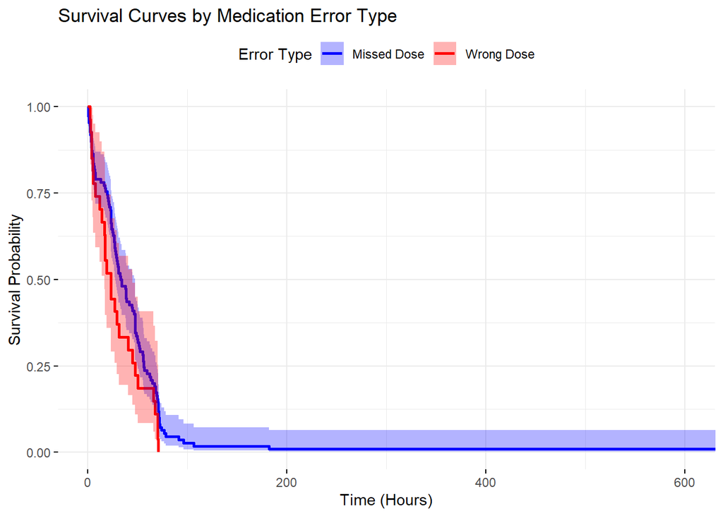

A log-rank test shows no significant difference between the survival curves (p-value = 0.0622), meaning there is no difference in reporting times between Missed Doses and Wrong doses, Additionally, the missed dose survival curve closely mirrors the overall survival curve, suggesting that missed doses may have a significant impact on the overall outcome, likely due to the higher frequency of missed dose cases compared to other error types.

Reporting an wrong dose takes less time than reporting a missed dose. By 33.34 hours $50\%$ of missed dose cases are reported. By 23.26 hours $50\%$ of wrong dose cases are reported. While this difference is not statistically significant, I was curious as to why missed doses are more common than incorrect doses, but it takes longer to report a missed dose compared to an incorrect dose. To better understand the dynamics behind these reporting times, I decided to look at a comparison between reporting times and needs level.

I chose not to plot the Kaplan-Meier survival curves for Needs.Level, as plotting five curves seemed excessive. However, the following table summarizes the survival analysis for each Needs.Level:

| Needs.Level | Events | rmean | se(rmean) | Median | 0.95LCL | 0.95UCL |
| --- | --- | --- | --- | --- | --- | --- |
| 1 | 7 | 20.01 | 6.76 | 17.06 | 4.34 | NA |
| 2 | 36 | 56.70 | 17.94 | 38.05 | 27.98 | 55.80 |
| 4 | 65 | 36.23 | 3.23 | 29.96 | 23.26 | 47.61 |
| 6 | 24 | 40.83 | 8.19 | 28.91 | 18.72 | 67.39 |
| 7 | 15 | 29.42 | 3.97 | 26.83 | 21.24 | 41.34 |

Following this, a log-rank test was conducted, which revealed no significant difference in the survival curves across the Needs.Level groups (p-value = 0.0764). Given that there is no difference in the Needs.Levels across medication errors (including Missed and Wrong Dose), there must be other factors influencing why Missed Dose is the most common, yet takes longer to report than Wrong Dose errors. These factors may include the reporter’s experience, environmental conditions, reporting complexity, and others that I unfortunately cannot explore from this dataset.

I will not put survival analysis in the presentation for Mainstay because the findings are not significant and does not really give us any insights that could help Mainstay. In addition, survival analysis is an advanced statistical method so it may not be suitable to present to an audience unfamiliar with this level of statistical knowledge.

## Conclusions

Mainstay Life Services has kept comprehensive records of medication errors, though the limited data on specific error types, such as discontinued medications, has weakens the analysis. But despite that I found that while medication errors related to missed and wrong doses have been increasing, recent years have seen a positive decline, which is encouraging. Additionally, I found that there is no interaction between the needs level and error type, meaning that errors are consistent across different levels of patients’ needs, which is a good sign. Furthermore, no significant difference was found in time-to-report across medication error types and needs level, indicating consistency in reporting practices.